# Árboles de clasificación y regresión con Rpart

Si ploteamos el árbol correspondiente tendremos

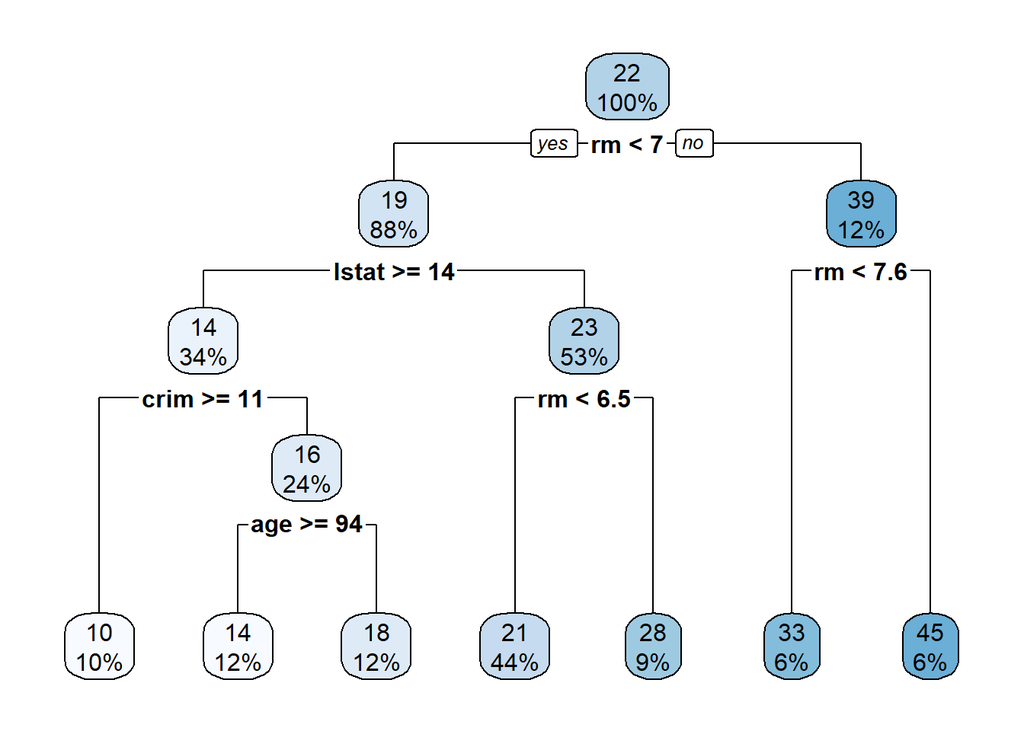

```r
rpart.plot(tree.boston)
```

De acuerdo con los resultados de la validación cruzada, podemos bien usar el árbol sin podar para hacer predicciones en el conjunto de prueba.

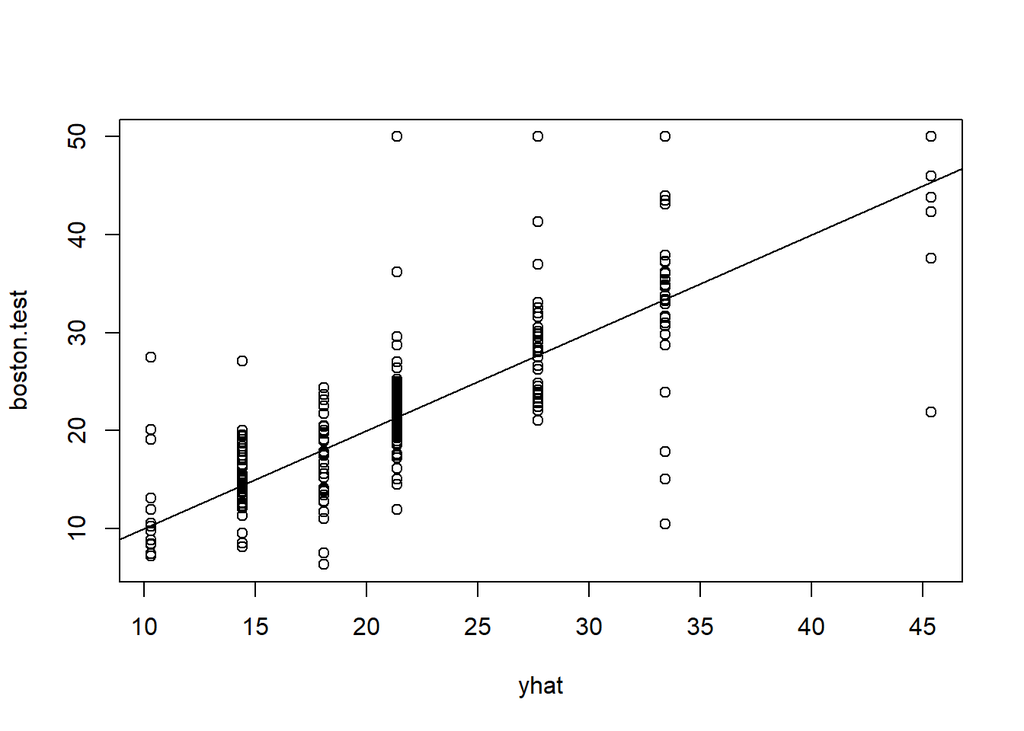

```r
yhat <- predict(tree.boston, newdata = Boston[-train, ])
boston.test <- Boston[-train, "medv"]
plot(yhat, boston.test)
abline(0, 1)
```

```r
mean((yhat - boston.test)^2)
```

```
## [1] 35.28688
```

En otras palabras, el MSE del conjunto de prueba asociado con el árbol de regresión es de 35.29. La raíz cuadrada del MSE es entonces aproximadamente 5.941, lo que indica que este modelo conduce a predicciones de prueba que están (en promedio) a unos 5,941 dólares del valor medio real de la vivienda para el sector censal.

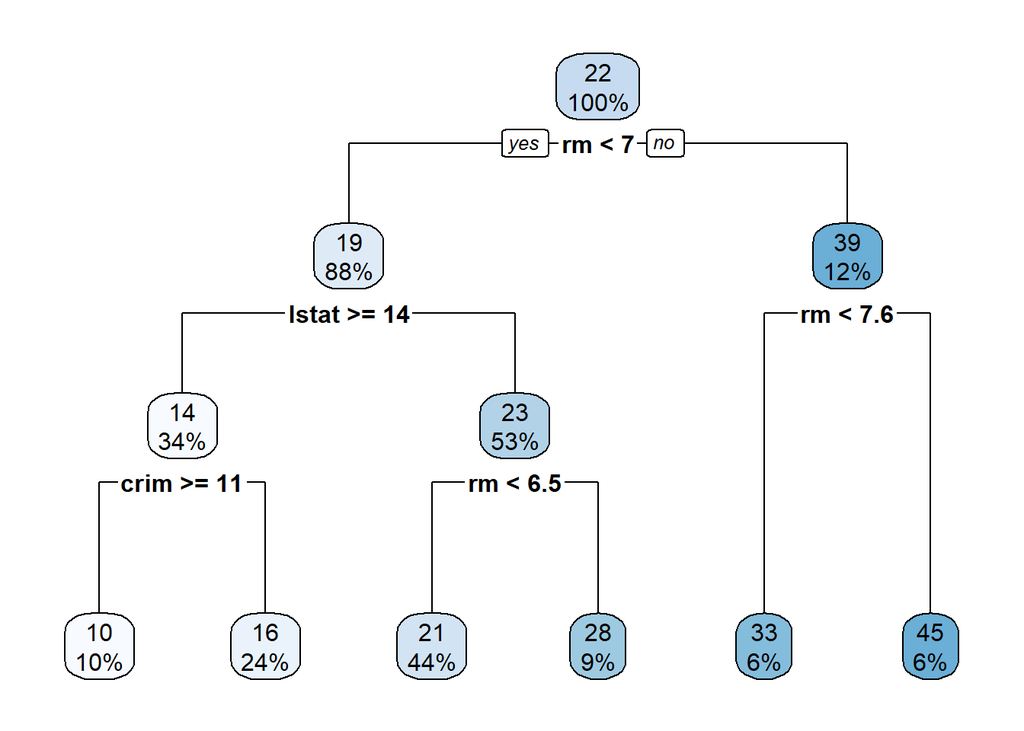

```r
fit4 <- prune(tree.boston, cp = 0.032)
rpart.plot(fit4)
```

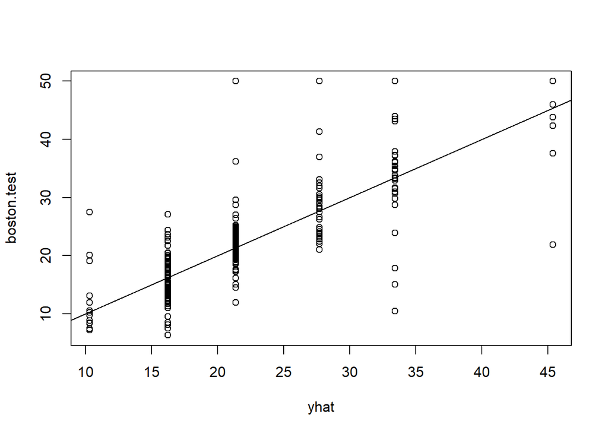

```r
yhat <- predict(fit4, newdata = Boston[-train, ])
boston.test <- Boston[-train, "medv"]
plot(yhat, boston.test)
abline(0, 1)
```

```r
mean((yhat - boston.test)^2)
```

```
## [1] 35.16439
```

E incluso obtenemos un error ligeramente mejor.

# 4 Ejercicios

## 4.1 Ejercicio 1

Dibuja un ejemplo (de tu propia invención) de una partición del espacio de características bidimensional que podría resultar de una división binaria recursiva. Tu ejemplo debe contener al menos seis regiones. Dibuja un árbol de decisión correspondiente a esta partición. Asegúrate de etiquetar todos los aspectos de tus figuras, incluidas las regiones $R_1,R_2,\ldots,$ los puntos de corte $t_1,t_2,\ldots$ y así sucesivamente.

## 4.2 Ejercicio 2

Considera el índice de Gini, el error de clasificación y la entropía en un problema de clasificación binario. Crea un solo gráfico que muestre cada una de estas cantidades como una función de $\hat{p}_{m1}$. El eje x debe mostrar $\hat{p}_{m1}$, desde 0 a 1, y el eje y debe mostrar el índice de Gini, la entropía y el error de clasificación. Nota que $\hat{p}_{m1}=1−\hat{p}_{m2}$ en un problema de clase binaria.

## 4.3 Ejercicio 3

Este problema implica el conjunto de datos OJ, que forma parte del paquete ISLR2.

```r
library(gtsummary)
data(OJ)
print(dfSummary(OJ), method = "render")
```

Data Frame Summary

OJ

**Dimensions**: 1070 x 18  
**Duplicates**: 24

| **No** | **Variable** | **Stats / Values** | **Freqs (% of Valid)** | **Graph** | **Valid** | **Missing** |
| --- | --- | --- | --- | --- | --- | --- |
| 1 | Purchase [factor] | 1. CH 2. MM | 653 ( 61.0% ) 417 ( 39.0% ) |  | 1070 (100.0%) | 0 (0.0%) |
| 2 | WeekofPurchase [numeric] | Mean (sd) : 254.4 (15.6) min ≤ med ≤ max: 227 ≤ 257 ≤ 278 IQR (CV) : 28 (0.1) | 52 distinct values |  | 1070 (100.0%) | 0 (0.0%) |
| 3 | StoreID [numeric] | Mean (sd) : 4 (2.3) min ≤ med ≤ max: 1 ≤ 3 ≤ 7 IQR (CV) : 5 (0.6) | 1 : 157 ( 14.7% ) 2 : 222 ( 20.7% ) 3 : 196 ( 18.3% ) 4 : 139 ( 13.0% ) 7 : 356 ( 33.3% ) |  | 1070 (100.0%) | 0 (0.0%) |
| 4 | PriceCH [numeric] | Mean (sd) : 1.9 (0.1) min ≤ med ≤ max: 1.7 ≤ 1.9 ≤ 2.1 IQR (CV) : 0.2 (0.1) | 1.69 : 94 ( 8.8% ) 1.75 : 95 ( 8.9% ) 1.76 : 40 ( 3.7% ) 1.79 : 101 ( 9.4% ) 1.86 : 376 ( 35.1% ) 1.89 : 42 ( 3.9% ) 1.96 : 29 ( 2.7% ) 1.99 : 259 ( 24.2% ) 2.06 : 7 ( 0.7% ) 2.09 : 27 ( 2.5% ) |  | 1070 (100.0%) | 0 (0.0%) |
| 5 | PriceMM [numeric] | Mean (sd) : 2.1 (0.1) min ≤ med ≤ max: 1.7 ≤ 2.1 ≤ 2.3 IQR (CV) : 0.2 (0.1) | 1.69 : 57 ( 5.3% ) 1.79 : 35 ( 3.3% ) 1.99 : 179 ( 16.7% ) 2.09 : 273 ( 25.5% ) 2.13 : 197 ( 18.4% ) 2.18 : 201 ( 18.8% ) 2.23 : 88 ( 8.2% ) 2.29 : 40 ( 3.7% ) |  | 1070 (100.0%) | 0 (0.0%) |
| 6 | DiscCH [numeric] | Mean (sd) : 0.1 (0.1) min ≤ med ≤ max: 0 ≤ 0 ≤ 0.5 IQR (CV) : 0 (2.3) | 12 distinct values |  | 1070 (100.0%) | 0 (0.0%) |
| 7 | DiscMM [numeric] | Mean (sd) : 0.1 (0.2) min ≤ med ≤ max: 0 ≤ 0 ≤ 0.8 IQR (CV) : 0.2 (1.7) | 12 distinct values |  | 1070 (100.0%) | 0 (0.0%) |
| 8 | SpecialCH [numeric] | Min : 0 Mean : 0.1 Max : 1 | 0 : 912 ( 85.2% ) 1 : 158 ( 14.8% ) |  | 1070 (100.0%) | 0 (0.0%) |
| 9 | SpecialMM [numeric] | Min : 0 Mean : 0.2 Max : 1 | 0 : 897 ( 83.8% ) 1 : 173 ( 16.2% ) |  | 1070 (100.0%) | 0 (0.0%) |
| 10 | LoyalCH [numeric] | Mean (sd) : 0.6 (0.3) min ≤ med ≤ max: 0 ≤ 0.6 ≤ 1 IQR (CV) : 0.5 (0.5) | 553 distinct values |  | 1070 (100.0%) | 0 (0.0%) |
| 11 | SalePriceMM [numeric] | Mean (sd) : 2 (0.3) min ≤ med ≤ max: 1.2 ≤ 2.1 ≤ 2.3 IQR (CV) : 0.4 (0.1) | 18 distinct values |  | 1070 (100.0%) | 0 (0.0%) |
| 12 | SalePriceCH [numeric] | Mean (sd) : 1.8 (0.1) min ≤ med ≤ max: 1.4 ≤ 1.9 ≤ 2.1 IQR (CV) : 0.1 (0.1) | 13 distinct values |  | 1070 (100.0%) | 0 (0.0%) |
| 13 | PriceDiff [numeric] | Mean (sd) : 0.1 (0.3) min ≤ med ≤ max: -0.7 ≤ 0.2 ≤ 0.6 IQR (CV) : 0.3 (1.9) | 36 distinct values |  | 1070 (100.0%) | 0 (0.0%) |
| 14 | Store7 [factor] | 1. No 2. Yes | 714 ( 66.7% ) 356 ( 33.3% ) |  | 1070 (100.0%) | 0 (0.0%) |
| 15 | PctDiscMM [numeric] | Mean (sd) : 0.1 (0.1) min ≤ med ≤ max: 0 ≤ 0 ≤ 0.4 IQR (CV) : 0.1 (1.7) | 18 distinct values |  | 1070 (100.0%) | 0 (0.0%) |
| 16 | PctDiscCH [numeric] | Mean (sd) : 0 (0.1) min ≤ med ≤ max: 0 ≤ 0 ≤ 0.3 IQR (CV) : 0 (2.3) | 13 distinct values |  | 1070 (100.0%) | 0 (0.0%) |
| 17 | ListPriceDiff [numeric] | Mean (sd) : 0.2 (0.1) min ≤ med ≤ max: 0 ≤ 0.2 ≤ 0.4 IQR (CV) : 0.2 (0.5) | 18 distinct values |  | 1070 (100.0%) | 0 (0.0%) |
| 18 | STORE [numeric] | Mean (sd) : 1.6 (1.4) min ≤ med ≤ max: 0 ≤ 2 ≤ 4 IQR (CV) : 3 (0.9) | 0 : 356 ( 33.3% ) 1 : 157 ( 14.7% ) 2 : 222 ( 20.7% ) 3 : 196 ( 18.3% ) 4 : 139 ( 13.0% ) |  | 1070 (100.0%) | 0 (0.0%) |

Generated by summarytools 1.0.1 ([R](https://www.r-project.org/) version 4.4.1)  
2024-11-14

Crea un conjunto de entrenamiento que contenga una muestra aleatoria de 800 observaciones y un conjunto de prueba con las observaciones restantes.

2. Ajusta un árbol rpart a los datos de entrenamiento, con Purchase como la respuesta y las otras variables como predictores. Usa la función summary() para producir estadísticas de resumen sobre el árbol y describe los resultados obtenidos. ¿Cuál sería el mejor árbol? ¿Cuántos nodos terminales tiene el árbol?
3. Escribe el nombre del objeto árbol para obtener una salida detallada en texto. Elige uno de los nodos terminales e interpreta la información mostrada.
4. Crea un gráfico del árbol e interpreta los resultados.
5. Predice la respuesta en los datos de prueba y produce una matriz de confusión comparando las etiquetas de prueba con las etiquetas de prueba predichas. ¿Cuál es la tasa de error de prueba?
6. Aplica la función printcp() al conjunto de entrenamiento para determinar el tamaño óptimo del árbol.
7. Produce un gráfico con el tamaño del árbol en el eje x y la tasa de error de clasificación validada cruzada en el eje y.
8. ¿Qué tamaño de árbol corresponde a la tasa de error de clasificación validada cruzada más baja?
9. Produce un árbol podado correspondiente al tamaño óptimo del árbol obtenido utilizando validación cruzada. Si la validación cruzada no lleva a la selección de un árbol podado, entonces crea un árbol podado con cinco nodos terminales.
10. Compara las tasas de error de entrenamiento entre los árboles podados y no podados. ¿Cuál es mayor?
11. Compara las tasas de error de prueba entre los árboles podados y no podados. ¿Cuál es mayor?